# Seoul Bike Rental Prediction

Ilgiz Almukhametov

2025-03-08

# Executive Summary

# Introduction

Bike-sharing programs have become an integral part of urban transportation, providing an affordable, convenient, and environmentally friendly alternative to motorized vehicles. These systems allow individuals to rent bicycles from designated stations and return them to any other station within the same network. As metropolitan areas worldwide continue to adopt bike-sharing schemes, they offer numerous benefits, including reduced traffic congestion, lower greenhouse gas emissions, and improved public health through active mobility. Additionally, their low cost incentivizes users to integrate cycling into their daily commutes, further contributing to sustainable urban development.

Accurately predicting bike rental demand is crucial for optimizing bike availability, minimizing operational inefficiencies, and ensuring a smooth user experience. An imbalance in bike distribution can lead to shortages in high-demand areas or excess bicycles in low-usage zones, reducing the overall effectiveness of the system. Therefore, developing a robust predictive model for bike rentals can aid city planners and policymakers in making data-driven decisions to enhance transportation efficiency.

The objective of this study is to leverage machine learning techniques to develop a regression model that forecasts bike rental demand based on various environmental, temporal, and seasonal factors. By analyzing data from Seoul’s bike-sharing system, this project aims to uncover key patterns that influence rental trends. The findings will provide valuable insights for government officials and urban mobility planners, enabling them to optimize bike allocation, improve maintenance strategies, and even introduce dynamic pricing models based on weather conditions.

# Data Understanding

## Data source

The dataset used in this project, titled “Seoul Bike Sharing Demand,” was sourced from the UCI Machine Learning Repository:  
https://archive.ics.uci.edu/dataset/560/seoul+bike+sharing+demand

It comprises hourly records of public bicycle rentals in Seoul, South Korea, along with corresponding weather conditions and date information. The dataset was donated on February 29, 2020, and is publicly accessible under a Creative Commons Attribution 4.0 International (CC BY 4.0) license.

## Description of Features

The dataset contains 8,760 instances and 14 features, detailed as follows:

- Date: The specific day of the record, formatted as day/month/year.
- Rented Bike Count: The number of bikes rented at each hour.
- Hour: The hour of the day (0 to 23).
- Temperature (°C): The temperature in degrees Celsius.
- Humidity (%): The relative humidity percentage.
- Wind Speed (m/s): The wind speed in meters per second.
- Visibility (10m): Visibility in units of 10 meters.
- Dew Point Temperature (°C): The dew point temperature in degrees Celsius.
- Solar Radiation (MJ/m²): Solar radiation in megajoules per square meter.
- Rainfall (mm): Rainfall amount in millimeters.
- Snowfall (cm): Snowfall amount in centimeters.
- Seasons: Categorical variable indicating the season — Winter, Spring, Summer, or Autumn.
- Holiday: Binary variable indicating whether the day is a holiday (Yes) or not (No).
- Functional Day: Binary variable indicating whether the hour is functional (Yes) or non-functional (No), with non-functional hours typically due to maintenance or other factors.

# Exploratory data analysis (EDA)

## Data Loading and Inspection:

- Loading the dataset
- Displaying the first few rows to understand the dataset structure
- Printing dataset dimensions (number of rows and columns) for a quick overview

```r
# Define file path
file_path <- "../data/SeoulBikeData.csv"

# Check if file exists before loading
if (!file.exists(file_path)) {
  stop("Error: File 'SeoulBikeData.csv' not found. Please check the working directory.")
}

# Load dataset
BikeData <- read_csv(file_path, show_col_types = FALSE, locale = locale(encoding = "ISO-8859-9"))

# Display the first few rows to understand the structure
print(head(BikeData), width = Inf)
```

```
## # A tibble: 6 × 14
##   Date       `Rented Bike Count`  Hour `Temperature(°C)` `Humidity(%)`
##   <chr>                    <dbl> <dbl>             <dbl>         <dbl>
## 1 01/12/2017                 254     0              -5.2            37
## 2 01/12/2017                 204     1              -5.5            38
## 3 01/12/2017                 173     2              -6              39
## 4 01/12/2017                 107     3              -6.2            40
## 5 01/12/2017                  78     4              -6              36
## 6 01/12/2017                 100     5              -6.4            37
##   `Wind speed (m/s)` `Visibility (10m)` `Dew point temperature(°C)`
##                <dbl>              <dbl>                       <dbl>
## 1                2.2               2000                       -17.6
## 2                0.8               2000                       -17.6
## 3                1                 2000                       -17.7
## 4                0.9               2000                       -17.6
```

[output cut: 18 more lines]

```r
# Print dataset dimensions
cat("Dataset contains", nrow(BikeData), "rows and", ncol(BikeData), "columns.\n")
```

```
## Dataset contains 8760 rows and 14 columns.
```

## Dataset Examination:

- Identify the presence of missing values in the dataset.
- Check for any duplicate records that may affect data integrity.
- Summarize key statistical properties of the dataset to understand distributions and trends.

```r
# Checking for missing values by column
missing_values <- colSums(is.na(BikeData))
missing_values <- missing_values[missing_values > 0]

if (length(missing_values) > 0) {
  cat("Columns with missing values:\n")
  print(missing_values)
} else {
  cat("No missing values detected in the dataset.\n\n")
}
```

```
## No missing values detected in the dataset.
```

```r
# Check for duplicate rows
duplicate_rows <- sum(duplicated(BikeData))
cat("Number of duplicate rows:", duplicate_rows, "\n\n")
```

```
## Number of duplicate rows: 0
```

```r
# Generate descriptive statistics
cat("Descriptive statistics:\n\n")
```

```
## Descriptive statistics:
```

```r
summary(BikeData)
```

```
##      Date           Rented Bike Count      Hour       Temperature(°C)
##  Length:8760        Min.   :   0.0    Min.   : 0.00   Min.   :-17.80
##  Class :character   1st Qu.: 191.0    1st Qu.: 5.75   1st Qu.:  3.50
##  Mode  :character   Median : 504.5    Median :11.50   Median : 13.70
##                     Mean   : 704.6    Mean   :11.50   Mean   : 12.88
##                     3rd Qu.:1065.2    3rd Qu.:17.25   3rd Qu.: 22.50
##                     Max.   :3556.0    Max.   :23.00   Max.   : 39.40
##   Humidity(%)    Wind speed (m/s) Visibility (10m) Dew point temperature(°C)
##  Min.   : 0.00   Min.   :0.000    Min.   :  27     Min.   :-30.600
##  1st Qu.:42.00   1st Qu.:0.900    1st Qu.: 940     1st Qu.: -4.700
##  Median :57.00   Median :1.500    Median :1698     Median :  5.100
##  Mean   :58.23   Mean   :1.725    Mean   :1437     Mean   :  4.074
##  3rd Qu.:74.00   3rd Qu.:2.300    3rd Qu.:2000     3rd Qu.: 14.800
##  Max.   :98.00   Max.   :7.400    Max.   :2000     Max.   : 27.200
##  Solar Radiation (MJ/m2)  Rainfall(mm)     Snowfall (cm)       Seasons
##  Min.   :0.0000          Min.   : 0.0000   Min.   :0.00000   Length:8760
##  1st Qu.:0.0000          1st Qu.: 0.0000   1st Qu.:0.00000   Class :character
##  Median :0.0100          Median : 0.0000   Median :0.00000   Mode  :character
##  Mean   :0.5691          Mean   : 0.1487   Mean   :0.07507
##  3rd Qu.:0.9300          3rd Qu.: 0.0000   3rd Qu.:0.00000
##  Max.   :3.5200          Max.   :35.0000   Max.   :8.80000
##    Holiday          Functioning Day
##  Length:8760        Length:8760
##  Class :character   Class :character
##  Mode  :character   Mode  :character
##
##
##
```

**Key Insights from Dataset Examination:**

## Data Preprocessing:

- Renaming columns for better readability and usage.
- Converting the Date column to the proper Date format.
- Creating a full Datetime column by combining Date and Hour.
- Extracting Month as a categorical variable.
- Converting categorical variables into factors.
- Setting locale to ensure correct month names.

```r
# Set locale to ensure month names are in English
Sys.setlocale("LC_TIME", "C")
```

```
## [1] "C"
```

```r
# Renaming columns for better readability
colnames(BikeData) <- c("Date", "RentedBikeCount", "Hour", "Temperature", "Humidity",
                        "WindSpeed", "Visibility", "DewPointTemperature", "SolarRadiation",
                        "Rainfall", "Snowfall", "Seasons", "Holiday", "FunctioningDay")

# Convert Date column to proper Date format
BikeData$Date <- as.Date(BikeData$Date, format="%d/%m/%Y")

# Create a full datetime column
BikeData$Datetime <- as.POSIXct(paste(BikeData$Date, BikeData$Hour), format="%Y-%m-%d %H")

# Create a Month categorical variable
BikeData$Month <- factor(month(BikeData$Datetime, label = TRUE, abbr = FALSE))

# Convert categorical variables to factors
factor_vars <- c("Hour", "Month", "Seasons", "Holiday", "FunctioningDay")
BikeData[factor_vars] <- lapply(BikeData[factor_vars], factor)

# Select categorical and date variables
categorical_date_vars <- BikeData[, sapply(BikeData, function(x) is.character(x) |
                                                         is.factor(x) |
                                                         inherits(x, "Date"))]

# Display summary statistics for categorical and date variables
summary(categorical_date_vars)
```

```
##       Date                 Hour        Seasons           Holiday
##  Min.   :2017-12-01   0      : 365   Autumn:2184   Holiday   : 432
##  1st Qu.:2018-03-02   1      : 365   Spring:2208   No Holiday:8328
##  Median :2018-06-01   2      : 365   Summer:2208
##  Mean   :2018-06-01   3      : 365   Winter:2160
##  3rd Qu.:2018-08-31   4      : 365
##  Max.   :2018-11-30   5      : 365
##                       (Other):6570
##  FunctioningDay     Month
##  No : 295       January: 744
##  Yes:8465       March  : 744
##                 May    : 744
##                 July   : 744
##                 August : 744
##                 October: 744
##                 (Other):4296
```

**Summary of Categorical and Date Variables:**

## Response Variable Analysis

- Distribution of Bike Rentals.
- Hourly Bike Rentals Over Time.
- Short-Term Trends in Peak Season.

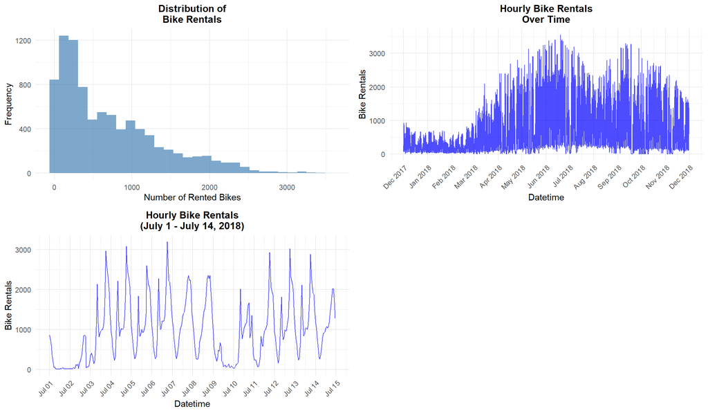

```r
# Histogram of bike rentals
p1 <- ggplot(BikeData, aes(x = RentedBikeCount)) +
  geom_histogram(fill = "steelblue", bins = 30, alpha = 0.7) +
  labs(title = "Distribution of\nBike Rentals", x = "Number of Rented Bikes", y = "Frequency") +
  theme_minimal() +
  theme(plot.title = element_text(size = 12, face = "bold", hjust = 0.5))

# Full Time Series Plot
p2 <- ggplot(BikeData, aes(x = Datetime, y = RentedBikeCount)) +
  geom_line(color = "blue", alpha = 0.7) +
  labs(title = "Hourly Bike Rentals\nOver Time", x = "Datetime", y = "Bike Rentals") +
  theme_minimal() +
  theme(axis.text.x = element_text(angle = 45, hjust = 1),
        plot.title = element_text(size = 12, face = "bold", hjust = 0.5)) +
  scale_x_datetime(date_breaks = "1 month", date_labels = "%b %Y")

# Filter for two weeks in summer (July 1 to July 14, 2018)
summer_weeks <- BikeData %>% filter(Date >= "2018-07-01", Date <= "2018-07-14")

# Time Series Plot for 2 Weeks in Summer
p3 <- ggplot(summer_weeks, aes(x = Datetime, y = RentedBikeCount)) +
  geom_line(color = "blue", alpha = 0.7) +
  labs(title = "Hourly Bike Rentals\n(July 1 - July 14, 2018)", x = "Datetime", y = "Bike Rentals") +
  theme_minimal() +
  theme(axis.text.x = element_text(angle = 45, hjust = 1),
        plot.title = element_text(size = 12, face = "bold", hjust = 0.5)) +
  scale_x_datetime(date_breaks = "1 day", date_labels = "%b %d")

# Display plots with reduced height and side-by-side layout
grid.arrange(p1, p2, p3, ncol = 2, heights = c(1, 1))
```

**Summary of Response Variable: RentedBikeCount**

1. Right-Skewed Distribution – The rental count follows a skewed distribution, resembling a Poisson-like pattern with most values concentrated at lower counts.
2. Seasonal Trends – Rentals peak in summer and drop in winter, reflecting strong seasonal effects.
3. Daily Patterns – Clear demand spikes during morning and evening peak hours, likely driven by commuter usage.
4. Potential for Feature Engineering – Incorporating working vs. non-working days and seasonal variations could enhance predictive modeling.

### Categorical variables vs response var

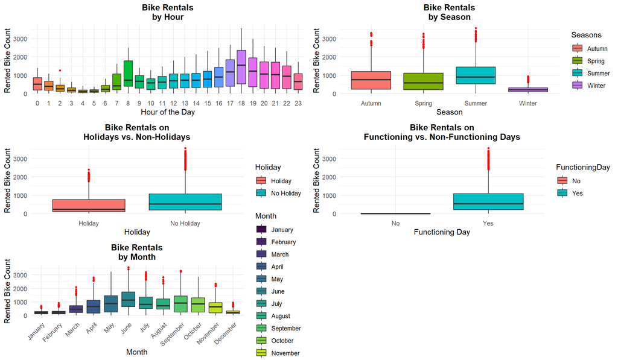

```r
# 1️⃣ Boxplot: Bike Rentals by Hour
p1 <- ggplot(BikeData, aes(x = Hour, y = RentedBikeCount, fill = Hour)) +
  geom_boxplot(outlier.color = "red", outlier.size = 1) +
  labs(title = "Bike Rentals\nby Hour", x = "Hour of the Day", y = "Rented Bike Count") +
  theme_minimal() +
  theme(legend.position = "none",
        plot.title = element_text(size = 12, face = "bold", hjust = 0.5))

# 2️⃣ Boxplot: Bike Rentals by Season
p2 <- ggplot(BikeData, aes(x = Seasons, y = RentedBikeCount, fill = Seasons)) +
  geom_boxplot(outlier.color = "red", outlier.size = 1) +
  labs(title = "Bike Rentals\nby Season", x = "Season", y = "Rented Bike Count") +
  theme_minimal() +
  theme(plot.title = element_text(size = 12, face = "bold", hjust = 0.5))

# 3️⃣ Boxplot: Bike Rentals on Holidays vs. Non-Holidays
p3 <- ggplot(BikeData, aes(x = Holiday, y = RentedBikeCount, fill = Holiday)) +
  geom_boxplot(outlier.color = "red", outlier.size = 1) +
  labs(title = "Bike Rentals on\nHolidays vs. Non-Holidays", x = "Holiday", y = "Rented Bike Count") +
  theme_minimal() +
  theme(plot.title = element_text(size = 12, face = "bold", hjust = 0.5))

# 4️⃣ Boxplot: Bike Rentals on Functioning vs. Non-Functioning Days
p4 <- ggplot(BikeData, aes(x = FunctioningDay, y = RentedBikeCount, fill = FunctioningDay)) +
  geom_boxplot(outlier.color = "red", outlier.size = 1) +
  labs(title = "Bike Rentals on\nFunctioning vs. Non-Functioning Days", x = "Functioning Day", y = "Rented Bike Count") +
  theme_minimal() +
  theme(plot.title = element_text(size = 12, face = "bold", hjust = 0.5))

# 5️⃣ Boxplot: Bike Rentals by Month
p5 <- ggplot(BikeData, aes(x = Month, y = RentedBikeCount, fill = Month)) +
  geom_boxplot(outlier.color = "red", outlier.size = 1) +
  labs(title = "Bike Rentals\nby Month", x = "Month", y = "Rented Bike Count") +
  theme_minimal() +
  theme(axis.text.x = element_text(angle = 45, hjust = 1),
        plot.title = element_text(size = 12, face = "bold", hjust = 0.5))

# Arrange plots in a grid (2 columns, 3 rows for better alignment)
grid.arrange(p1, p2, p3, p4, p5, ncol = 2, nrow = 3)
```

**Summary of Categorical Variables Influence:**

1. Hour matters: Bike rentals peak during commuting hours (7-9 AM & 5-9 PM).
2. Seasonality has a strong effect: Highest rentals in summer, moderate in spring & autumn, lowest in winter.
3. Holidays slightly reduce demand: Likely due to lower work-related commuting.
4. Functioning days confirm expectations: No rentals on non-operational days.
5. Using months instead of seasons might provide better granularity: Monthly trends could reveal more precise patterns.

## Data Transformation

**Removing FunctioningDay Variable**

The FunctioningDay variable indicates whether the bike-sharing system was operational. On non-operational days (FunctioningDay = No), no rentals occurred (RentedBikeCount = 0) due to system closure.

Since these zero-rental days result from external constraints rather than natural demand fluctuations, keeping them may introduce noise and distort analysis. To maintain analytical integrity, these rows, along with the variable itself, will be removed.

```r
# Remove non-functioning days and drop the column in one step
BikeData <- BikeData %>%
  dplyr::filter(FunctioningDay == "Yes") %>%
  dplyr::select(-FunctioningDay)
```

**Weekdays vs. weekends Analysis**

Analyzing both holidays and weekdays vs. weekends provides deeper insight into bike rental behavior. Since holidays can occur on any day, their impact may be inconsistent, whereas weekdays and weekends naturally differentiate commuting from leisure trends.

- If weekends and holidays show similar rental patterns, it suggests a leisure-driven usage trend.
- If weekdays exhibit higher demand, it highlights a commuter-driven pattern.

**Creating “Weekday” vs. “Weekend” Variable**

```r
# Ensure system locale does not affect weekday names
Sys.setlocale("LC_TIME", "C")
```

```
## [1] "C"
```

```r
# Create "Weekday" vs. "Weekend" variable using numeric values
BikeData$DayType <- ifelse(wday(BikeData$Date) %in% c(1, 7), "Weekend", "Weekday")

# Convert to factor
BikeData$DayType <- as.factor(BikeData$DayType)

# Verify distribution
table(BikeData$DayType)
```

```
##
## Weekday Weekend
##    6024    2441
```

**Comparing Bike Rental Trends: Weekdays, Weekends, and Holidays**

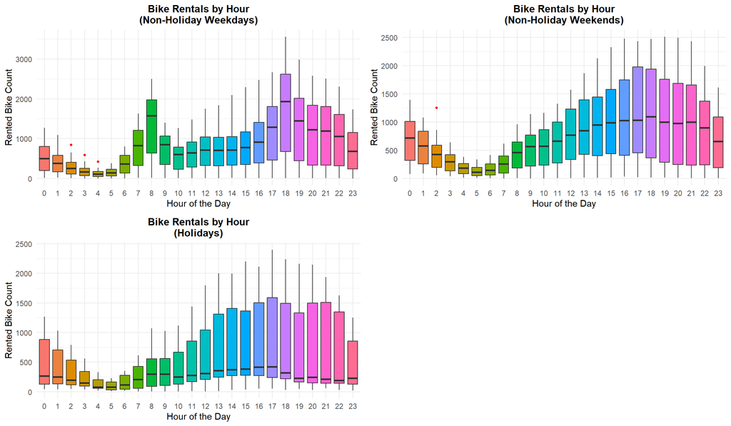

```r
# Subset Data
NonHoliday_Weekdays <- BikeData %>% filter(Holiday == "No Holiday", DayType == "Weekday")
NonHoliday_Weekends <- BikeData %>% filter(Holiday == "No Holiday", DayType == "Weekend")
Holidays <- BikeData %>% filter(Holiday == "Holiday")

# Function to create boxplots
create_boxplot <- function(data, title) {
  ggplot(data, aes(x = Hour, y = RentedBikeCount, fill = Hour)) +
    geom_boxplot(outlier.color = "red", outlier.size = 1) +
    labs(title = title, x = "Hour of the Day", y = "Rented Bike Count") +
    theme_minimal() +
    theme(legend.position = "none",
          plot.title = element_text(size = 12, face = "bold", hjust = 0.5))
}

# Generate plots
p1 <- create_boxplot(NonHoliday_Weekdays, "Bike Rentals by Hour\n(Non-Holiday Weekdays)")
p2 <- create_boxplot(NonHoliday_Weekends, "Bike Rentals by Hour\n(Non-Holiday Weekends)")
p3 <- create_boxplot(Holidays, "Bike Rentals by Hour\n(Holidays)")

# Arrange plots in a grid (3 side by side)
grid.arrange(p1, p2, p3, ncol = 2)
```

Summary:

- Weekdays show commute-driven demand, with sharp peaks during morning (7-9 AM) and evening (5-9 PM) rush hours.
- Weekends and holidays follow leisure-driven patterns, with a gradual increase throughout the day, peaking in the afternoon.
- Holidays resemble weekends, suggesting that bike-sharing demand depends more on activity context than just the calendar.

**Creating the WorkdayType Variable**

To simplify the dataset without losing relevant information, the original DayType and Holiday variables will be removed after merging.

```r
# Create WorkdayType variable: "Workday" vs. "Non-Workday"
BikeData$WorkdayType <- ifelse(BikeData$Holiday == "Yes" | BikeData$DayType == "Weekend", "Non-Workday", "Workday")

# Convert to factor
BikeData$WorkdayType <- as.factor(BikeData$WorkdayType)

# Remove redundant columns
BikeData <- BikeData %>% dplyr::select(-DayType, -Holiday)
```

## Visualizing Distributions of Numerical Features

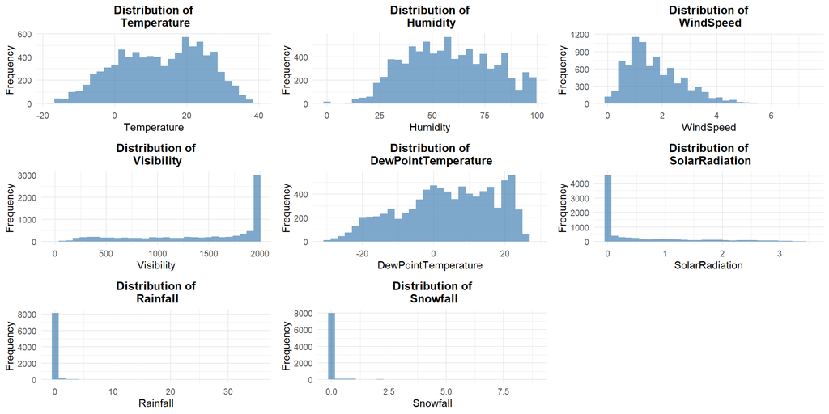

```r
# List of continuous variables to plot
continuous_vars <- c("Temperature", "Humidity", "WindSpeed", "Visibility",
                     "DewPointTemperature", "SolarRadiation", "Rainfall", "Snowfall")

# Generate histogram plots
plots <- lapply(continuous_vars, function(var) {
  ggplot(BikeData, aes(x = .data[[var]])) +
    geom_histogram(fill = "steelblue", bins = 30, alpha = 0.7) +
    labs(title = paste("Distribution of\n", var), x = var, y = "Frequency") +
    theme_minimal() +
    theme(plot.title = element_text(size = 12, face = "bold", hjust = 0.5))  # Centered title
})

# Arrange plots in a grid (3 per row)
grid.arrange(grobs = plots, ncol = 3)
```

**Summary of Continuous Variables:**

**Creating Binary Indicators for Extreme Distributions**

Since Visibility, Solar Radiation, Rainfall, and Snowfall exhibit highly skewed distributions, with values predominantly concentrated at a single point and occasional deviations, adding binary indicators can help capture meaningful variations. Introducing these variables enhances interpretability and allows for a more effective analysis of their impact on bike rentals:

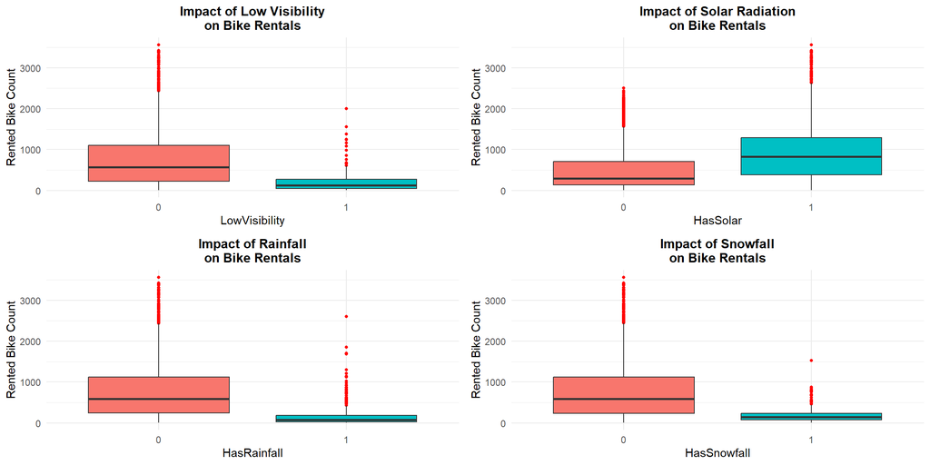

```r
# Create indicator variables
BikeData <- BikeData %>%
  mutate(
    LowVisibility = ifelse(Visibility < 250, 1, 0),
    HasSolar = ifelse(SolarRadiation > 0, 1, 0),
    HasRainfall = ifelse(Rainfall > 0, 1, 0),
    HasSnowfall = ifelse(Snowfall > 0, 1, 0)
  )

# Convert to factor
BikeData <- BikeData %>%
  mutate(across(c(LowVisibility, HasSolar, HasRainfall, HasSnowfall), as.factor))

# Function to create boxplots for binary variables
create_boxplot <- function(var, title) {
  ggplot(BikeData, aes(x = .data[[var]], y = RentedBikeCount, fill = .data[[var]])) +
    geom_boxplot(outlier.color = "red", outlier.size = 1) +
    labs(title = title, x = var, y = "Rented Bike Count") +
    theme_minimal() +
    theme(legend.position = "none",
          plot.title = element_text(size = 12, face = "bold", hjust = 0.5))  # Centered title
}

# Generate plots
p1 <- create_boxplot("LowVisibility", "Impact of Low Visibility\non Bike Rentals")
p2 <- create_boxplot("HasSolar", "Impact of Solar Radiation\non Bike Rentals")
p3 <- create_boxplot("HasRainfall", "Impact of Rainfall\non Bike Rentals")
p4 <- create_boxplot("HasSnowfall", "Impact of Snowfall\non Bike Rentals")

# Arrange plots in a 2x2 grid
grid.arrange(p1, p2, p3, p4, ncol = 2, nrow = 2)
```

**Impact of Environmental Factors on Bike Rentals:**

These insights validate the importance of environmental conditions in bike-sharing demand. The creation of binary indicators proves useful in distinguishing the impact of extreme weather conditions, making these features potentially valuable for predictive modeling.

**Numerical variables vs response var**

Since the response variable RentedBikeCount represents count data, it follows a Poisson-like distribution. Count data often exhibit right skewness, which can distort relationships in regression models. To address this, it is better to analyze both:

- Raw count values to observe direct relationships with environmental factors.
- Log-transformed values to stabilize variance and improve linearity.

The following visualization presents scatter plots of bike rentals vs. numerical variables in a controlled subset (Workdays, No Precipitation (95% of data), Midday Hours, and a specific Season) to better isolate trends. This selection helps reduce variability caused by external factors, making it easier to observe distinct relationships between variables. Both raw and log-transformed responses are displayed side by side for clarity.

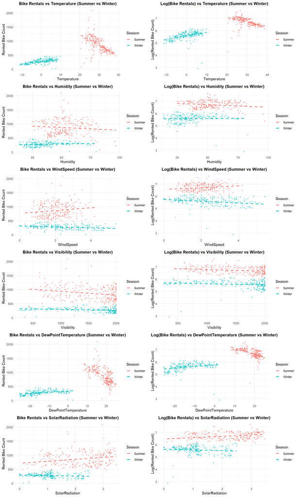

```r
# Filter dataset for Workdays, No Precipitation, and Midday Hours (11 AM - 2 PM)
filtered_data <- BikeData %>%
  filter(
    WorkdayType == "Workday" & HasRainfall == 0
    & HasSnowfall == 0 & LowVisibility == 0
    & Hour %in% c(11, 12, 13, 14)
    & Seasons %in% c("Summer", "Winter")  # Keep only Summer & Winter for comparison
  )

# Apply log transformation to the response variable (adding +1 to avoid log(0))
filtered_data <- filtered_data %>%
  mutate(LogRentedBikeCount = log(RentedBikeCount + 1))

# List of continuous variables to plot
continuous_vars <- c("Temperature", "Humidity", "WindSpeed", "Visibility",
                     "DewPointTemperature", "SolarRadiation")

# Function to create paired scatter plots (Raw vs Log Response)
create_scatterplots <- function(var) {
  # Scatter plot for raw count response
  p1 <- ggplot(filtered_data, aes(x = .data[[var]], y = RentedBikeCount, color = Seasons)) +
    geom_point(alpha = 0.5, size = 1) +  # Color points by season
    geom_smooth(method = "lm", se = FALSE, linetype = "dashed", aes(color = Seasons)) +  # Separate trend lines
    labs(title = paste("Bike Rentals vs", var, "(Summer vs Winter)"),
         x = var, y = "Rented Bike Count", color = "Season") +
    theme_minimal() +
    theme(plot.title = element_text(size = 12, face = "bold", hjust = 0.5))

  # Scatter plot for log-transformed response
  p2 <- ggplot(filtered_data, aes(x = .data[[var]], y = LogRentedBikeCount, color = Seasons)) +
    geom_point(alpha = 0.5, size = 1) +  # Color points by season
    geom_smooth(method = "lm", se = FALSE, linetype = "dashed", aes(color = Seasons)) +  # Separate trend lines
    labs(title = paste("Log(Bike Rentals) vs", var, "(Summer vs Winter)"),
         x = var, y = "Log(Rented Bike Count)", color = "Season") +
    theme_minimal() +
    theme(plot.title = element_text(size = 12, face = "bold", hjust = 0.5))

  return(list(p1, p2))  # Return both plots as a list
}

# Generate plots for all continuous variables
all_plots <- unlist(lapply(continuous_vars, create_scatterplots), recursive = FALSE)

# Arrange plots in a grid (2 per row: Raw vs Log)
grid.arrange(grobs = all_plots, ncol = 2)
```

**Key Takeaways from Scatter Plots:**

- Since the response variable exhibits right skewness and the relationships with the independent variables become more linear after log transformation due to variance stabilization, applying a logarithmic transformation is preferable for linear modeling.
- Seasonality is a critical factor, with significantly lower rentals in Winter on all graphs.
- Temperature is a key predictor with opposite slopes in Summer (negative) and Winter (positive). Interaction terms (Temperature × Season) should be included in linear models.
- Some of the graphs also have different slopes depending on the season, suggesting that interactions of variables need to be taken into account when constructing a linear regression.
- Poisson and Negative Binomial models should be tested for count data.
- Some variables show low predictive power (almost zero slope), especially in winter.

```r
# because there are no zeros in the data
BikeData$LogRentedBikeCount <- log(BikeData$RentedBikeCount)
```

**Correlation Matrix Analysis:**

Correlation matrices are constructed for each season. To minimize external influences, the analysis focuses on workdays, no precipitation (covering ~95% of the data), midday hours with similar demand, and high visibility conditions. This controlled subset helps isolate seasonal patterns in bike rental behavior.

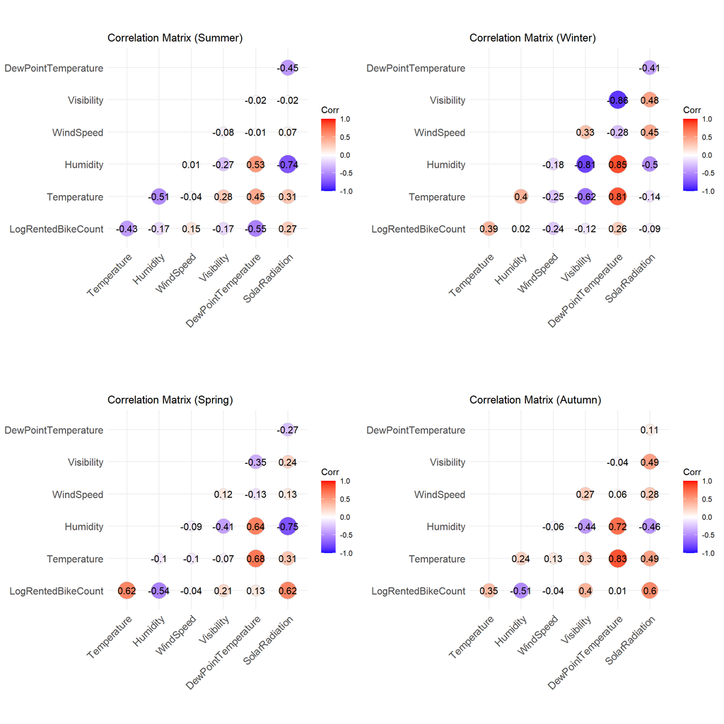

```r
# Filter dataset separately for each season
summer_data <- BikeData %>%
  filter(
    WorkdayType == "Workday" & HasRainfall == 0
    & HasSnowfall == 0 & LowVisibility == 0
    & Hour %in% c(11, 12, 13, 14) &
    Seasons == "Summer"
  )

winter_data <- BikeData %>%
  filter(
    WorkdayType == "Workday" & HasRainfall == 0
    & HasSnowfall == 0 & LowVisibility == 0
    & Hour %in% c(11, 12, 13, 14) &
    Seasons == "Winter"
  )

spring_data <- BikeData %>%
  filter(
    WorkdayType == "Workday" & HasRainfall == 0
    & HasSnowfall == 0 & LowVisibility == 0
    & Hour %in% c(11, 12, 13, 14) &
    Seasons == "Spring"
  )

autumn_data <- BikeData %>%
  filter(
    WorkdayType == "Workday" & HasRainfall == 0
    & HasSnowfall == 0 & LowVisibility == 0
    & Hour %in% c(11, 12, 13, 14) &
    Seasons == "Autumn"
  )

# Select only numeric variables for correlation analysis
numeric_vars <- c("LogRentedBikeCount", "Temperature", "Humidity", "WindSpeed", "Visibility",
                  "DewPointTemperature", "SolarRadiation")

# Compute correlation matrices
summer_cor_matrix <- cor(summer_data %>% dplyr::select(all_of(numeric_vars)), use = "complete.obs")
winter_cor_matrix <- cor(winter_data %>% dplyr::select(all_of(numeric_vars)), use = "complete.obs")
spring_cor_matrix <- cor(spring_data %>% dplyr::select(all_of(numeric_vars)), use = "complete.obs")
autumn_cor_matrix <- cor(autumn_data %>% dplyr::select(all_of(numeric_vars)), use = "complete.obs")

# Generate correlation plots
p1 <- ggcorrplot(summer_cor_matrix, method = "circle", type = "lower",
                 lab = TRUE, lab_size = 4, colors = c("blue", "white", "red"),
                 title = "Correlation Matrix (Summer)", ggtheme = theme_minimal())

p2 <- ggcorrplot(winter_cor_matrix, method = "circle", type = "lower",
                 lab = TRUE, lab_size = 4, colors = c("blue", "white", "red"),
                 title = "Correlation Matrix (Winter)", ggtheme = theme_minimal())

p3 <- ggcorrplot(spring_cor_matrix, method = "circle", type = "lower",
                 lab = TRUE, lab_size = 4, colors = c("blue", "white", "red"),
                 title = "Correlation Matrix (Spring)", ggtheme = theme_minimal())

p4 <- ggcorrplot(autumn_cor_matrix, method = "circle", type = "lower",
                 lab = TRUE, lab_size = 4, colors = c("blue", "white", "red"),
                 title = "Correlation Matrix (Autumn)", ggtheme = theme_minimal())

# Arrange all four plots in a grid (2x2)
grid.arrange(p1, p2, p3, p4, ncol = 2, nrow = 2)
```

**Key Findings from the Correlation Matrix:**

- Temperature is a key predictor, exhibiting a positive correlation in Spring, Autumn, and Winter, but a negative correlation in Summer. This suggests the need to account for seasonal interactions with temperature, potentially incorporating polynomial terms to model non-linear effects across different seasons.
- Humidity shows negligible correlation in Winter and Summer but demonstrates a strong negative correlation in Spring and Autumn. Given that precipitation is excluded from the analysis, this may indicate that high humidity negatively impacts bike demand in these seasons due to wet or muddy road conditions.
- Wind Speed has a minimal effect in Summer, Spring, and Autumn, implying little influence on rental demand. However, in Winter, higher wind speeds slightly reduce bike rentals, likely due to increased discomfort in cold conditions.
- Visibility is only significant in Autumn (0.4), suggesting that clearer visibility conditions may encourage higher demand during this season.
- Dew Point Temperature exhibits strong correlations in Winter and Summer, with opposite signs similar to temperature, indicating that it may capture seasonal effects related to temperature-driven demand patterns.
- Solar Radiation shows a significant positive correlation in Spring and Autumn, emphasizing the impact of sunny weather on increased bike demand during these transitional seasons.

**Key Modeling Considerations:**

- Include interaction terms (Temperature × Season, Humidity × Season, DewPointTemperature × Season, SolarRadiation × Season) to capture season-dependent effects.
- Consider polynomial terms for Temperature and Humidity to account for non-linear relationships observed in some seasons.
- Test excluding Wind Speed and Visibility due to their weak or inconsistent correlations with bike rentals.

# Modelling

## Linear Regression

Linear regression is a fundamental statistical method that serves as a reliable baseline for predictive analysis. Before applying complex machine learning algorithms, it is essential to develop a simple and interpretable model to assess linear relationships in the data and the significance of key predictors.

In this section, two linear regression models are built:  
- **Basic Model**: Includes key environmental and temporal predictors.  
- **Enhanced Model**: Incorporates polynomial features and interaction terms to capture non-linear effects and seasonal dependencies.

```r
# Select relevant variables
model_data <- BikeData %>%
  dplyr::select(RentedBikeCount, LogRentedBikeCount, Hour, Temperature, Humidity, WindSpeed, Visibility, DewPointTemperature, SolarRadiation, Rainfall, Snowfall,
                Seasons, Month, WorkdayType, LowVisibility, HasSolar, HasRainfall, HasSnowfall)

# Convert categorical variables to factors
factor_vars <- c("Hour", "Month", "Seasons", "WorkdayType", "LowVisibility", "HasSolar", "HasRainfall", "HasSnowfall")
model_data[factor_vars] <- lapply(model_data[factor_vars], as.factor)

# Add polynomial features for Temperature and Humidity
model_data <- model_data %>%
  mutate(
    Temperature2 = Temperature^2,
    Temperature3 = Temperature^3,
    Humidity2 = Humidity^2,
    Humidity3 = Humidity^3
  )

# Split into train/test sets
set.seed(123)
train_index <- createDataPartition(model_data$LogRentedBikeCount, p = 0.8, list = FALSE)
train_data <- model_data[train_index, ]
test_data <- model_data[-train_index, ]

# Fit linear regression model basic
lm_model1 <- lm(LogRentedBikeCount ~ Temperature + Humidity + WindSpeed + Visibility +
               SolarRadiation + Rainfall + Snowfall + Seasons +
               Hour + WorkdayType + LowVisibility + HasSolar + HasRainfall + HasSnowfall,
               data = train_data)

lm_model2 <- lm(LogRentedBikeCount ~ Temperature + Humidity + WindSpeed +
                  SolarRadiation + Rainfall + Snowfall + Month +
                  Hour + WorkdayType + LowVisibility + HasSolar + HasRainfall +
                  Month * Temperature + Month * Humidity +
                  Hour * WorkdayType + Temperature2 + Temperature3 + Humidity2 + Humidity3 +
                  HasSnowfall, data = train_data)

# Summary of linear regression models
print(summary(lm_model1))
```

```
##
## Call:
## lm(formula = LogRentedBikeCount ~ Temperature + Humidity + WindSpeed +
##     Visibility + SolarRadiation + Rainfall + Snowfall + Seasons +
##     Hour + WorkdayType + LowVisibility + HasSolar + HasRainfall +
##     HasSnowfall, data = train_data)
##
## Residuals:
##     Min      1Q  Median      3Q     Max
## -4.1643 -0.2297  0.0602  0.3129  3.2740
##
## Coefficients:
##                      Estimate Std. Error t value Pr(>|t|)
## (Intercept)         6.694e+00  6.436e-02 104.018  < 2e-16 ***
## Temperature         3.605e-02  1.321e-03  27.294  < 2e-16 ***
## Humidity           -9.386e-03  5.688e-04 -16.503  < 2e-16 ***
## WindSpeed          -3.855e-02  7.735e-03  -4.983 6.41e-07 ***
## Visibility         -3.581e-05  1.488e-05  -2.406  0.01614 *
## SolarRadiation      2.755e-02  1.657e-02   1.663  0.09631 .
## Rainfall           -1.322e-01  7.743e-03 -17.070  < 2e-16 ***
## Snowfall           -6.792e-02  2.221e-02  -3.058  0.00224 **
## SeasonsSpring      -2.925e-01  2.052e-02 -14.257  < 2e-16 ***
## SeasonsSummer      -2.242e-01  2.513e-02  -8.920  < 2e-16 ***
## SeasonsWinter      -8.329e-01  2.847e-02 -29.252  < 2e-16 ***
## Hour1              -2.423e-01  4.589e-02  -5.280 1.33e-07 ***
## Hour2              -5.274e-01  4.628e-02 -11.395  < 2e-16 ***
## Hour3              -8.555e-01  4.635e-02 -18.457  < 2e-16 ***
## Hour4              -1.299e+00  4.723e-02 -27.514  < 2e-16 ***
## Hour5              -1.292e+00  4.674e-02 -27.635  < 2e-16 ***
## Hour6              -6.189e-01  4.679e-02 -13.227  < 2e-16 ***
## Hour7              -1.059e-01  4.947e-02  -2.140  0.03239 *
## Hour8               3.144e-01  5.451e-02   5.767 8.45e-09 ***
## Hour9              -1.193e-01  5.777e-02  -2.066  0.03889 *
## Hour10             -4.925e-01  5.975e-02  -8.243  < 2e-16 ***
## Hour11             -4.510e-01  6.190e-02  -7.286 3.56e-13 ***
## Hour12             -3.214e-01  6.283e-02  -5.115 3.22e-07 ***
## Hour13             -3.518e-01  6.302e-02  -5.583 2.46e-08 ***
## Hour14             -3.582e-01  6.233e-02  -5.746 9.51e-09 ***
## Hour15             -2.768e-01  6.138e-02  -4.509 6.62e-06 ***
## Hour16             -1.578e-01  5.865e-02  -2.690  0.00717 **
## Hour17              6.353e-02  5.754e-02   1.104  0.26961
## Hour18              4.809e-01  5.434e-02   8.851  < 2e-16 ***
## Hour19              3.164e-01  4.933e-02   6.414 1.51e-10 ***
## Hour20              3.075e-01  4.776e-02   6.438 1.29e-10 ***
## Hour21              4.618e-01  4.649e-02   9.933  < 2e-16 ***
## Hour22              2.964e-01  4.572e-02   6.482 9.68e-11 ***
## Hour23              5.864e-02  4.646e-02   1.262  0.20692
## WorkdayTypeWorkday  1.744e-01  1.498e-02  11.638  < 2e-16 ***
## LowVisibility1     -2.727e-01  4.120e-02  -6.618 3.91e-11 ***
## HasSolar1           2.634e-01  3.230e-02   8.154 4.17e-16 ***
## HasRainfall1       -1.461e+00  3.636e-02 -40.176  < 2e-16 ***
## HasSnowfall1        6.774e-02  4.674e-02   1.449  0.14729
## ---
## Signif. codes:  0 '***' 0.001 '**' 0.01 '*' 0.05 '.' 0.1 ' ' 1
##
## Residual standard error: 0.5526 on 6735 degrees of freedom
## Multiple R-squared:  0.7743, Adjusted R-squared:  0.773
## F-statistic: 607.9 on 38 and 6735 DF,  p-value: < 2.2e-16
```

```r
print(summary(lm_model2))
```

```
##
## Call:
## lm(formula = LogRentedBikeCount ~ Temperature + Humidity + WindSpeed +
##     SolarRadiation + Rainfall + Snowfall + Month + Hour + WorkdayType +
##     LowVisibility + HasSolar + HasRainfall + Month * Temperature +
##     Month * Humidity + Hour * WorkdayType + Temperature2 + Temperature3 +
##     Humidity2 + Humidity3 + HasSnowfall, data = train_data)
##
## Residuals:
##     Min      1Q  Median      3Q     Max
## -4.3629 -0.1619  0.0360  0.2151  2.9398
##
## Coefficients:
##                             Estimate Std. Error t value Pr(>|t|)
## (Intercept)                6.206e+00  1.296e-01  47.896  < 2e-16 ***
## Temperature                5.886e-02  5.859e-03  10.047  < 2e-16 ***
## Humidity                  -3.871e-02  5.024e-03  -7.705 1.50e-14 ***
## WindSpeed                 -3.084e-02  6.371e-03  -4.840 1.33e-06 ***
## SolarRadiation             1.122e-01  1.499e-02   7.487 7.98e-14 ***
## Rainfall                  -1.103e-01  6.363e-03 -17.334  < 2e-16 ***
## Snowfall                  -5.695e-02  1.911e-02  -2.979 0.002899 **
## Month.L                    5.881e-01  9.880e-02   5.953 2.77e-09 ***
## Month.Q                    6.929e-01  2.611e-01   2.654 0.007964 **
## Month.C                    1.510e-01  1.507e-01   1.002 0.316156
## Month^4                   -1.161e+00  1.831e-01  -6.341 2.43e-10 ***
## Month^5                   -8.936e-01  1.635e-01  -5.465 4.80e-08 ***
## Month^6                    2.461e-01  1.420e-01   1.733 0.083170 .
## Month^7                   -1.968e-01  1.606e-01  -1.226 0.220257
## Month^8                    2.462e-01  1.531e-01   1.607 0.108020
## Month^9                    8.995e-01  1.647e-01   5.460 4.93e-08 ***
## Month^10                   8.305e-01  1.857e-01   4.472 7.89e-06 ***
## Month^11                   1.363e-01  2.299e-01   0.593 0.553377
## Hour1                     -1.672e-01  6.971e-02  -2.399 0.016474 *
## Hour2                     -3.973e-01  6.810e-02  -5.834 5.65e-09 ***
## Hour3                     -6.932e-01  6.933e-02 -10.000  < 2e-16 ***
## Hour4                     -1.156e+00  7.237e-02 -15.977  < 2e-16 ***
## Hour5                     -1.592e+00  6.984e-02 -22.798  < 2e-16 ***
## Hour6                     -1.294e+00  7.024e-02 -18.429  < 2e-16 ***
## Hour7                     -1.069e+00  7.083e-02 -15.095  < 2e-16 ***
## Hour8                     -7.035e-01  7.451e-02  -9.441  < 2e-16 ***
```

[output cut: 60 more lines]

```
## Hour15:WorkdayTypeWorkday  9.722e-03  8.357e-02   0.116 0.907388
## Hour16:WorkdayTypeWorkday  1.248e-01  8.096e-02   1.541 0.123318
## Hour17:WorkdayTypeWorkday  3.275e-01  8.241e-02   3.973 7.16e-05 ***
## Hour18:WorkdayTypeWorkday  7.569e-01  8.239e-02   9.187  < 2e-16 ***
## Hour19:WorkdayTypeWorkday  5.037e-01  8.162e-02   6.170 7.21e-10 ***
## Hour20:WorkdayTypeWorkday  3.955e-01  8.317e-02   4.755 2.03e-06 ***
## Hour21:WorkdayTypeWorkday  4.821e-01  8.218e-02   5.866 4.68e-09 ***
## Hour22:WorkdayTypeWorkday  4.309e-01  8.146e-02   5.289 1.27e-07 ***
## Hour23:WorkdayTypeWorkday  2.602e-01  8.274e-02   3.145 0.001665 **
## ---
## Signif. codes:  0 '***' 0.001 '**' 0.01 '*' 0.05 '.' 0.1 ' ' 1
##
## Residual standard error: 0.446 on 6679 degrees of freedom
## Multiple R-squared:  0.8542, Adjusted R-squared:  0.8521
## F-statistic: 416.2 on 94 and 6679 DF,  p-value: < 2.2e-16
```

**Baseline vs. Enhanced Model Performance:**

- The baseline model achieves an R² of 0.774, while the enhanced model improves it to 0.854, indicating a significantly better explanatory power.
- The residual standard error (RSE) decreases from 0.5526 to 0.446, meaning the enhanced model provides a better fit and lower prediction error.
- These improvements suggest that incorporating polynomial transformations and interaction terms enhances the model’s ability to capture complex relationships.

### Residual Diagnostics and Model Validation of Linear Regression on Test Data.

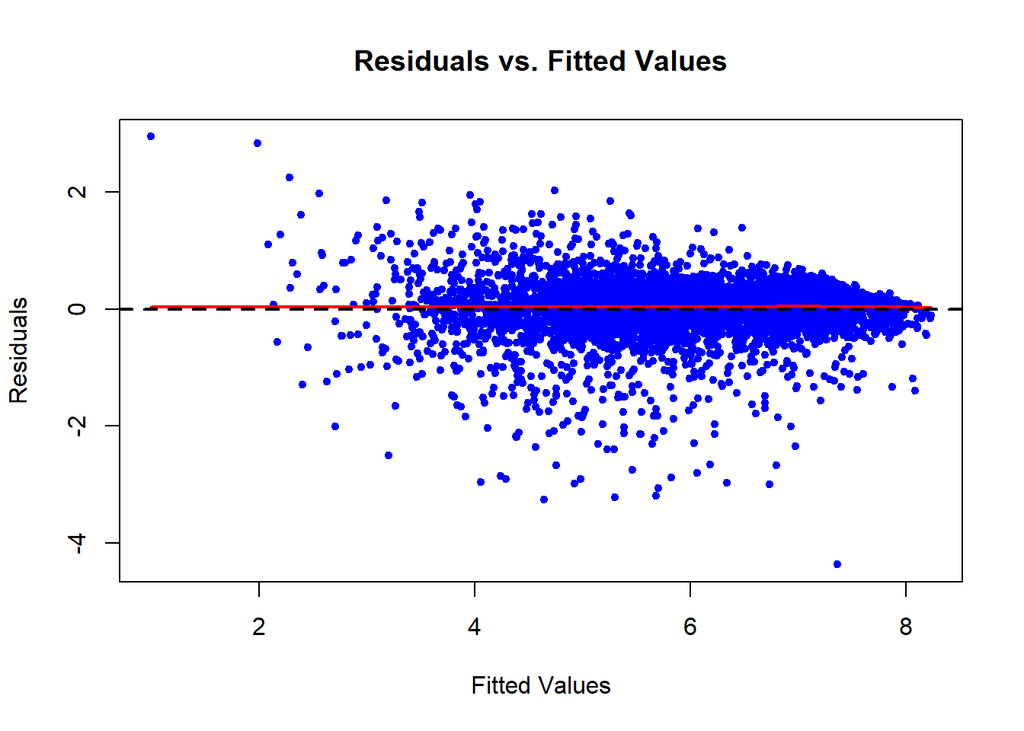

```r
# Residuals vs. Fitted Values plot
plot(lm_model2$fitted.values, lm_model2$residuals,
     xlab = "Fitted Values", ylab = "Residuals",
     main = "Residuals vs. Fitted Values",
     pch = 20, col = "blue")

# Add LOWESS smooth line (local regression)
lines(lowess(lm_model2$fitted.values, lm_model2$residuals), col = "red", lwd = 2)

# Add a horizontal reference line at 0
abline(h = 0, col = "black", lwd = 2, lty = 2)
```

```r
# Perform Breusch-Pagan test for heteroscedasticity
bptest(lm_model2)
```

```
##
##  studentized Breusch-Pagan test
##
## data:  lm_model2
## BP = 1336.5, df = 94, p-value < 2.2e-16
```

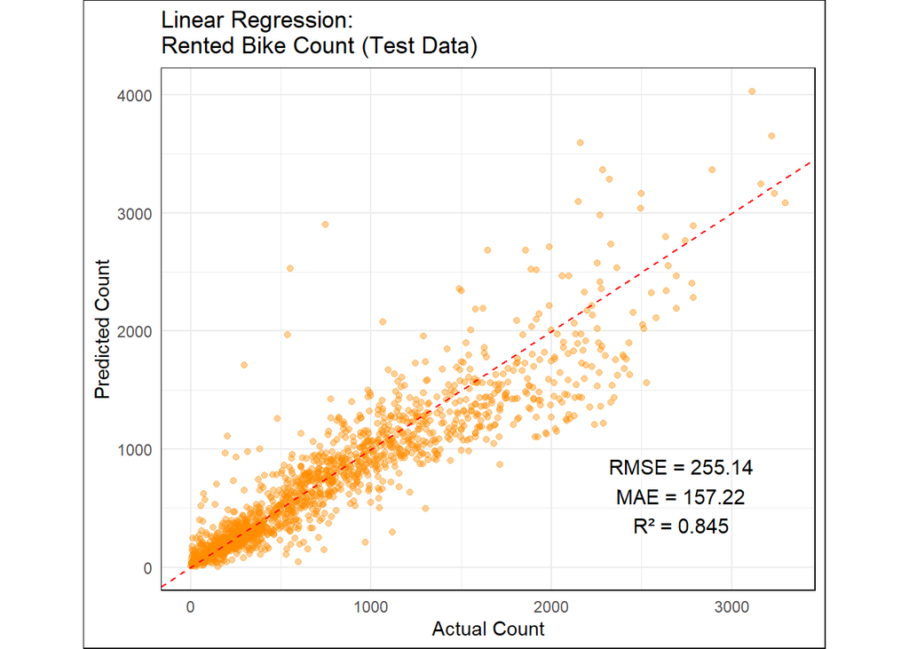

```r
# Predict on test data (log scale)
log_lm_pred <- predict(lm_model2, test_data)

# Reverse transformation (convert log predictions back to original scale)
lm_pred <- exp(log_lm_pred)

# Actual values from test data
test_y <- test_data$RentedBikeCount

# Function to compute evaluation metrics
calculate_metrics <- function(actual, predicted) {
  data.frame(
    RMSE = rmse(actual, predicted),
    MAE = mae(actual, predicted),
    R2 = cor(actual, predicted)^2
  )
}

# Evaluate model performance on test data
results <- calculate_metrics(test_y, lm_pred) %>%
  mutate(Model = "Linear Regression")

# Print evaluation results
# print(results)


# Scatter plot: Actual vs Predicted values with full external border
ggplot(data.frame(Actual = test_y, Predicted = lm_pred), aes(x = Actual, y = Predicted)) +
  geom_point(color = "darkorange", alpha = 0.4) +
  geom_abline(slope = 1, intercept = 0, color = "red", linetype = "dashed") +
  labs(
    title = "Linear Regression:\nRented Bike Count (Test Data)",
    x = "Actual Count",
    y = "Predicted Count"
  ) +
  theme_minimal() +
  theme(
    aspect.ratio = 0.8,  # Ensures a square plot
    plot.background = element_rect(color = "black", fill = NA, size = 0.5),
    panel.border = element_rect(color = "black", fill = NA, size = 0.5)
  ) +
  # Adding text with evaluation metrics inside the rectangle
  annotate("text", x = max(test_y) * 0.825, y = max(lm_pred) * 0.15,
           label = paste0("RMSE = ", round(results$RMSE, 2), "\n",
                          "MAE = ", round(results$MAE, 2), "\n",
                          "R² = ", round(results$R2, 3)),
           color = "black", hjust = 0.5, size = 4)
```

**Summary of Model Performance & Residual Analysis:**

- Residuals vs. Fitted Plot: The residuals show trends: on one side the dispersion narrows towards the edge, on the other side it expands, suggesting heteroscedasticity, meaning variance is not constant across fitted values.
- Breusch-Pagan Test: The test confirms heteroscedasticity (p-value < 2.2e-16), indicating that residual variance depends on predictors.
- Actual vs. Predicted Plot: Predictions closely follow the y = x line, indicating a strong correlation between actual and predicted values.
- R² Score: The R² value of 0.845 indicates that the model explains 84.5% of the variance in bike rentals.
- Overall Model Performance: While the model captures most variance well, heteroscedasticity suggests that error distribution may need further refinement, such as using weighted regression or transformation techniques.

Although the model improves significantly with polynomial features and interaction terms, the detected heteroscedasticity suggests the presence of complex relationships that have not been fully accounted for. To further enhance predictive performance, it is advisable to explore more advanced models, such as Poisson Regression (GLM with log link), Negative Binomial Regression (handles overdispersion), XGBoost, or random forest, which can better capture non-linear dependencies and intricate feature interactions.

## Advanced ML-models

```r
# Select relevant variables
model_data <- BikeData %>%
  dplyr::select(RentedBikeCount, Hour, Temperature, Humidity, WindSpeed, Visibility,
                DewPointTemperature, SolarRadiation, Rainfall, Snowfall,
                Month, WorkdayType, LowVisibility, HasSolar, HasRainfall, HasSnowfall)

# Convert categorical variables to factors (for Poisson, Negative Binomial, and Random Forest)
factor_vars <- c("Hour", "Month", "WorkdayType", "LowVisibility", "HasSolar", "HasRainfall", "HasSnowfall")
model_data[factor_vars] <- lapply(model_data[factor_vars], as.factor)

# Split data into train/test sets
set.seed(123)
train_index <- createDataPartition(model_data$RentedBikeCount, p = 0.8, list = FALSE)
train_data <- model_data[train_index, ]
test_data <- model_data[-train_index, ]

# One-Hot Encoding for XGBoost
dummies <- dummyVars(" ~ .", data = model_data, fullRank = TRUE)
model_data_xgb <- as.data.frame(predict(dummies, newdata = model_data))

# Prepare XGBoost train/test sets
train_xgb <- model_data_xgb[train_index, ] %>% dplyr::select(-RentedBikeCount)
test_xgb <- model_data_xgb[-train_index, ] %>% dplyr::select(-RentedBikeCount)

# Prepare data for other models
train_x <- train_data %>% dplyr::select(-RentedBikeCount)
train_y <- train_data$RentedBikeCount
test_x <- test_data %>% dplyr::select(-RentedBikeCount)
test_y <- test_data$RentedBikeCount

### 1. Poisson Regression Model
poisson_glm <- glm(RentedBikeCount ~ Temperature + Humidity + WindSpeed +
                    SolarRadiation + Rainfall + Snowfall + Month +
                    Hour + WorkdayType + LowVisibility + HasSolar + HasRainfall +
                    poly(Temperature, 3) + poly(Humidity, 3) +
                    Month * Temperature + Month * Humidity +
                    Hour * WorkdayType,
                    family = poisson(link = "log"),
                    data = train_data)

poisson_pred <- predict(poisson_glm, test_data, type = "response")

### 2. Negative Binomial Regression Model
neg_binom_model <- glm.nb(RentedBikeCount ~ Temperature + Humidity + WindSpeed +
                            SolarRadiation + Rainfall + Snowfall + Month +
                            Hour + WorkdayType + LowVisibility + HasSolar + HasRainfall +
                            poly(Temperature, 3) + poly(Humidity, 3) +
                            Month * Temperature + Month * Humidity +
                            Hour * WorkdayType,
                            data = train_data)

neg_binom_pred <- predict(neg_binom_model, test_data, type = "response")

### 3. Random Forest Model
set.seed(123)
rf_model <- randomForest(x = train_x, y = train_y, ntree = 500, mtry = 5)
rf_pred <- predict(rf_model, test_x)

### 4. XGBoost Model
set.seed(123)
xgb_train <- xgb.DMatrix(data = as.matrix(train_xgb), label = train_y)
xgb_test <- xgb.DMatrix(data = as.matrix(test_xgb))

xgb_model <- xgboost(data = xgb_train,
                     objective = "reg:squarederror",
                     nrounds = 200,
                     max_depth = 6,
                     eta = 0.1,
                     subsample = 0.8,
                     colsample_bytree = 0.8,
                     verbose = 0)

xgb_pred <- predict(xgb_model, xgb_test)

### Function to Calculate Evaluation Metrics
calculate_metrics <- function(true, pred) {
  data.frame(
    RMSE = rmse(true, pred),
    MAE = mae(true, pred),
    R2 = cor(true, pred)^2
  )
}

### Create Final Comparison Table
final_results <- bind_rows(
  calculate_metrics(test_y, poisson_pred) %>% mutate(Model = "Poisson Regression"),
  calculate_metrics(test_y, neg_binom_pred) %>% mutate(Model = "Negative Binomial Regression"),
  calculate_metrics(test_y, rf_pred) %>% mutate(Model = "Random Forest"),
  calculate_metrics(test_y, xgb_pred) %>% mutate(Model = "XGBoost")
)

# Print final results
print(final_results)
```

```
##       RMSE      MAE        R2                        Model
## 1 210.8888 128.3110 0.8922822           Poisson Regression
## 2 242.6199 145.7985 0.8585649 Negative Binomial Regression
## 3 191.2738 116.1147 0.9127567                Random Forest
## 4 184.2447 113.6172 0.9173503                      XGBoost
```

**Summary of Model Performance:**

In practice, the next logical step would be to further fine-tune the hyperparameters of the best-performing models to maximize predictive accuracy. However, as this project was conducted for portfolio purposes, the achieved results are already strong and sufficiently demonstrate advanced modeling techniques. Therefore, additional optimization can be considered outside the scope of this work.

Final scatterplot of actual and predicted values on XGBoost model test data:

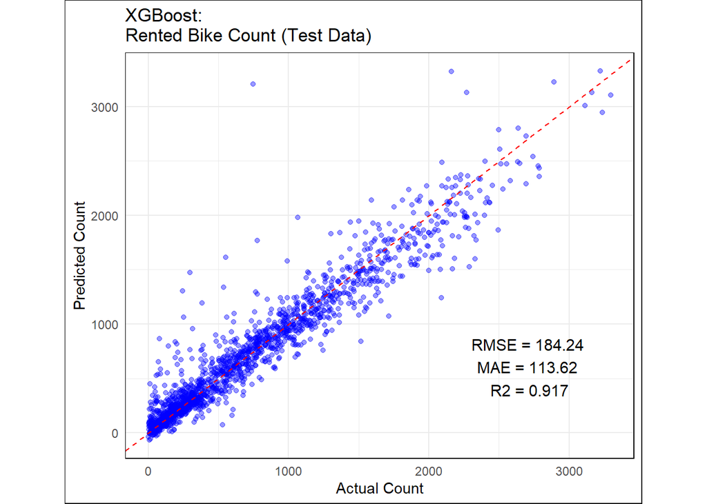

```r
# Create a dataframe for plotting
plot_data <- data.frame(
  Actual = test_y,
  XGB_Predicted = xgb_pred
)

# Model metrics for XGBoost
metrics_text_xgb <- paste(
  "RMSE =", round(final_results$RMSE[final_results$Model == "XGBoost"], 2),
  "\nMAE =", round(final_results$MAE[final_results$Model == "XGBoost"], 2),
  "\nR2 =", round(final_results$R2[final_results$Model == "XGBoost"], 3)
)

# Scatter plot: Actual vs Predicted values with full external border
p1 <- ggplot(plot_data, aes(x = Actual, y = XGB_Predicted)) +
  geom_point(color = "blue", alpha = 0.4) +
  geom_abline(slope = 1, intercept = 0, color = "red", linetype = "dashed") +
  labs(
    title = "XGBoost:\nRented Bike Count (Test Data)",
    x = "Actual Count",
    y = "Predicted Count"
  ) +
  theme_minimal() +
  theme(
    aspect.ratio = 0.8,  # Ensures a square plot
    plot.background = element_rect(color = "black", fill = NA, size = 0.5),
    panel.border = element_rect(color = "black", fill = NA, size = 0.5)
  ) +
  # Adding text with evaluation metrics inside the rectangle
  annotate("text", x = max(test_y) * 0.825, y = max(lm_pred) * 0.15,
           label = metrics_text_xgb,
           color = "black", hjust = 0.5, size = 4)

# Display plot
print(p1)
```

The XGBoost model shows strong predictive performance with an R² of 0.917, indicating a high correlation between actual and predicted values. Most points align well with the diagonal, suggesting accurate predictions, though some deviations appear at higher counts. The error metrics (RMSE = 184.24, MAE = 113.62) indicate relatively low prediction errors. Additionally, the data is densely concentrated at lower counts, which the model captures effectively.

### SHAP visualization

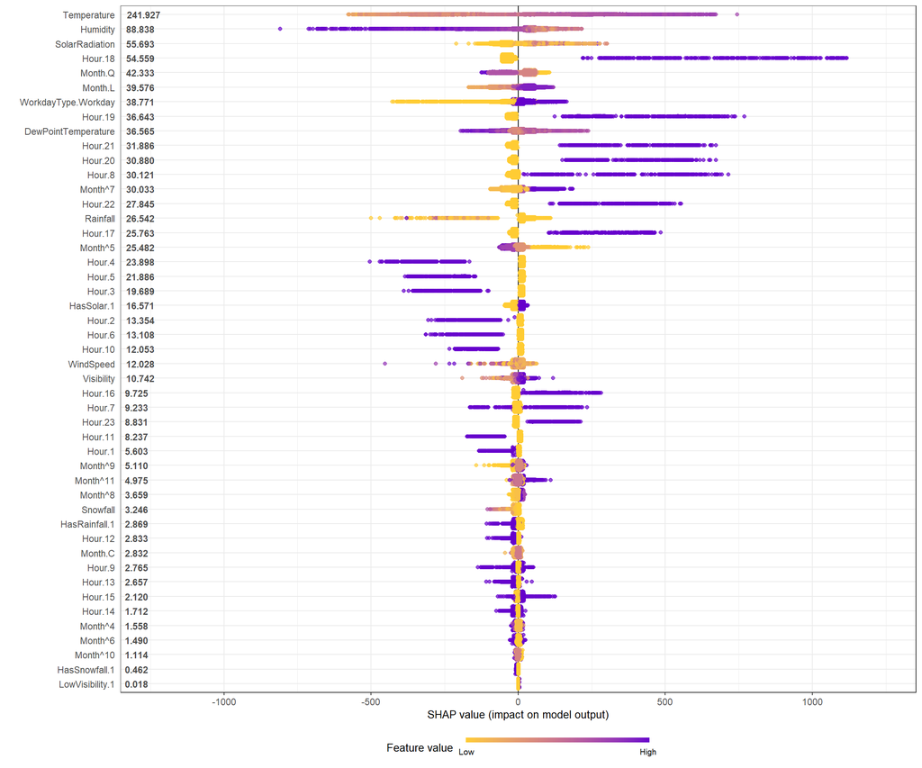

```r
# Ensure X_train is a matrix, not xgb.DMatrix
X_train_matrix <- as.matrix(train_xgb)

# Compute SHAP values
shap_values <- shap.values(xgb_model = xgb_model, X_train = X_train_matrix)

# Prepare data for visualization
shap_long <- shap.prep(xgb_model = xgb_model, X_train = X_train_matrix)

# Generate summary plot
shap.plot.summary(shap_long)
```

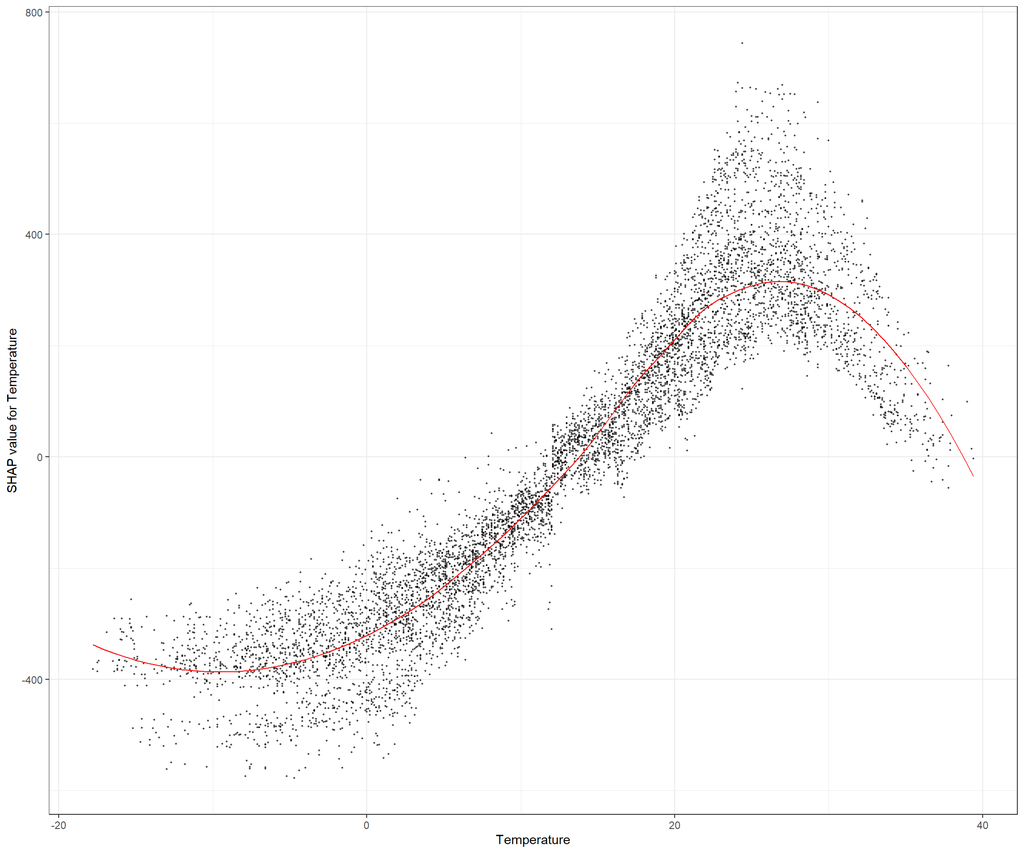

```r
# Generate dependence plot for a specific feature, e.g., 'Temperature'
shap.plot.dependence(data_long = shap_long, x = 'Temperature', y = 'Temperature')
```

Key Takeaways:

- **Temperature:** The most influential factor in bike sharing. Higher temperatures generally increase demand, while very low temperatures reduce it. However, the temperature SHAP plot shows that demand starts to decline when the temperature exceeds approximately 25°C.
- **Humidity:** A significant factor; high humidity tends to reduce bike usage, likely due to discomfort.
- **Solar Radiation:** Higher solar radiation is associated with increased bike rentals, possibly due to better weather conditions.
- **Hour of the Day:** Certain hours, such as morning and evening rush hours, have a strong positive effect due to commuting patterns.
- **Month:** Seasonality plays a role; warmer months tend to have higher demand, while colder months see reduced rentals.
- **Workday Type:** Demand differs between workdays and non-workdays, with workdays generally experiencing higher demand for bike sharing.
- **Dew Point Temperature:** High dew point values reduce demand, while lower values increase it.
- **Rainfall:** Even small amounts of rainfall negatively impact bike demand, discouraging usage.
- **Wind Speed & Visibility:** Moderate or low impact; strong winds and low visibility slightly reduce bike rentals.
- **Snowfall:** Negatively affects bike sharing, although its impact is lower than that of rainfall due to fewer snowfall events.

# Conclusion & Key Takeaways

This project successfully developed a predictive model for bike-sharing demand in Seoul, leveraging machine learning techniques to analyze key environmental and temporal factors. The findings highlight critical insights for urban mobility and resource optimization.

**Key Insights from the Analysis:**

**Potential Applications & Future Enhancements:**

- Smart Bike Redistribution – Insights from this model can help city officials dynamically allocate bikes based on predicted demand, reducing shortages in peak areas.
- Weather-Responsive Pricing & Promotions – Offering discounts during lower-demand weather conditions (e.g., high humidity, mild rain) could improve utilization rates.
- Real-Time Demand Forecasting – Integrating this model with IoT-based bike tracking could enable real-time adjustments, optimizing station availability and maintenance scheduling.
- Further Model Refinements – Fine-tuning hyperparameters and incorporating real-time traffic or event data could further improve prediction accuracy.

By demonstrating expertise in exploratory data analysis, feature engineering, and advanced machine learning techniques, this project showcases valuable skills in data science, predictive modeling, and urban analytics—essential for solving real-world mobility challenges.